###### Virtualisation et Cloud - © TEK-UP University

# LAB 1.2 : VirtualBox

### Objectif

L’objectif de ce TP est de maitriser les différents modes d'accès réseau d'une VM sur VirtualBox.

## Préparation des VMs

- Pour tester les modes d'accès réseau sur VirtualBox, on va créer deux VMs VM1 et VM2 par copie intégrale (Full clone) de la machine originale "Base-Ubuntu Desktop"

### Copie des machines

1. Arretez la VM.
2. Faites un clic droit sur la VM et sélectionnez "Clone".

[figure not shown]

3. Donnez le nom "VM1" à la copie et sélectionnez l'option "Generate new MAC addresses for all network adapters" sous "MAC Address Policy ".

[figure not shown]

4. Sélectionnez l'option "Full Clone" pour faire une copie intégrale.

[figure not shown]

5. Créer une deuxième copie de votre machine originale "Base-Ubuntu Desktop" et nommez la "VM2".

[figure not shown]

### Configuration de VM1 et VM2

- Les machines VM1 et VM2 sont obtenues par une copie intégrale (Full Clone) de la machine originale "Base-Ubuntu Desktop" donc VM1 et VM2 possèdent la même configuration que la machine "Base-Ubuntu Desktop"

- Avant d'utiliser les machines VM1 et VM2, on va leur affecter des noms d'hôtes (hostnames) différents

**Le nom d’hôte (hostname) est le nom d’un périphérique dans un réseau. On peut aussi le qualifier de nom de l’ordinateur et nom du site. Le nom d’hôte est utilisé pour distinguer les périphériques au sein d’un réseau local**

1. Démarrez les machines VM1 et VM2.
2. Pour chaque VM, éditez le fichier "/etc/hostname" et changez leurs noms d'hôtes par VM1 (machine VM1) et VM2 (machine VM2). Pour ouvrir les fichiers, tapez la commande suivante sur le terminal :

```python
sudo nano /etc/hostname
```

[figure not shown]

3. Tapez Ctr+X pour enregistrer
4. Editez le fichier "/etc/hosts" et changez le hostname par VM1 (machine VM1) / VM2 (machine VM2)

```python
sudo nano /etc/hosts
```

[figure not shown]

5. Tapez Ctr+X pour enregistrer
6. Pour que les modifications s'appliquent, redémarrez les deux machine et vérifiez que les nom d'hôtes se sont changés
- Résultat :

[figure not shown]

## Les modes d'accès réseau sur VirtualBox

### Adaptateur réseau

- Une VM possède un adaptateur réseau virtuel, Network Interface Controller (NIC), pour lui permettre de se connecter à Internet et communiquer avec d'autres VMs
- Chaque VM peut utiliser jusqu'à huit adaptateurs réseau virtuels dont seulement quatre sont configurables via la console graphique de VirtualBox (Interface graphique)
- L'adaptateur réseau est l'émulation logicielle d'un adaptateur réseau physique
- VirtualBox fournit plusieurs types d'adaptateurs réseau

[figure not shown]

### Les modes d'accès réseau

- Lors de la création de la VM, une configuration réseau par défaut est créée. La configuration par défaut permet la VM de se connecter à Internet
- VirtualBox définit plusieurs modes réseau :
  - Not Attached
  - NAT (par défaut)
  - NAT Network
  - Bridged Adapter
  - Internal Network
  - Host-Only Adapter
  - Generic Driver

[figure not shown]

## Mode accès réseau NAT

- La traduction d'adresses réseau (Network address translation , NAT) est le moyen le plus simple d'accéder à un réseau externe à partir d'une machine virtuelle.
- Habituellement, le mode NAT ne nécessite aucune configuration sur le réseau hôte et le système invité. Pour cette raison, il s'agit du mode réseau par défaut pour les hyperviseurs type 2
- La machine hôte effectue une translation d'adresse avant d'envoyer les paquets de la VM vers le réseau. Elle met son adresse IP en source du paquet et tient à jour une table de translation.
  - Lorsqu'une machine virtuelle envoie une demande d'accès à une ressource réseau, pour la ressource réseau la demande apparaît comme si en provenance de la machine hôte. NAT utilise les propres ressources réseau de l'hôte pour se connecter au réseau externe

### Configuration coté hyperviseur

- Le mode réseau NAT étant le mode par défaut sur VirtualBox. Donc les machines créées sont déja en mode réseau NAT

### Test

1. Démarrez les machines VM1 et VM2
2. Déterminez l'adresse et le masque réseau ainsi que l'adresse IP de votre machine physique (hôte), de VM1 et VM2 : utilisez la commande ipconfig (Windows)/ ifconfig (Linux, Mac OS)

|  | host | VM1 | VM2 |
| --- | --- | --- | --- |
| Adresse IP |  |  |  |
| Masque réseau |  |  |  |
| Adresse réseau |  |  |  |

**- Remarque : Si la commande "ifconfig" est inconnue par le système, tapez la commande suivante pour l'installer :**

```python
sudo apt install net-tools
```

3. Testez les connexions entre VMs, hôte et réseau Internet et complétez le tableau ci-dessous

| Mode | VM--> VM | VM --> host | host ---> VM | VM ---> Internet |
| --- | --- | --- | --- | --- |
| NAT |  |  |  |  |

## Mode accès réseau par pont : Bridged Adapter

- Ce mode connecte directement la VM à la même interface réseau que la machine hôte
- Les paquets réseau de la VM sont envoyés directement à l'interface réseau sans routage
  - VirtualBox utilise un pilote de périphérique sur le système hôte qui filtre les données en provenance de l'interface réseau et qui lui permet d'y injecter le traffic des données sortant

### Configuration coté hyperviseur

1. Changez les modes d'accès réseau des deux machines VM1 et VM2 à "Accès par pont / Bridged Adapter"

### Test

2. Déterminez l'adresse et le masque réseau ainsi que l'adresse IP de votre machine physique (hôte), de VM1 et VM2

|  | host | VM1 | VM2 |
| --- | --- | --- | --- |
| Adresse IP |  |  |  |
| Masque réseau |  |  |  |
| Adresse réseau |  |  |  |

3. Testez les connexions entre VMs, hôte et réseau Internet et complétez le tableau ci-dessous

| Mode | VM--> VM | VM --> host | host ---> VM | VM ---> Internet |
| --- | --- | --- | --- | --- |
| Bridge |  |  |  |  |

## Mode accès réseau privé : Internal Network

- Ce mode est simulaire au mode accès par pont (Bridge) dans le sens que la VM peut communiquer directement avec le monde extérieur. Cependant, le monde extérieur est limité aux autres machines virtuelles du même hôte qui se connectent au même réseau interne
  - Mode utilisé pour configurer un réseau interne isolé aux VMs
- Chaque réseau interne est identifié simplement par son nom

### Configuration coté hyperviseur

1. Arretez les VMS et changez les modes d'accès réseau des deux machines VM1 et VM2 à "Réseau privé / Internal Network"
2. Donnez un nouveau au réseau interne : intnet1 pour VM1 et VM2

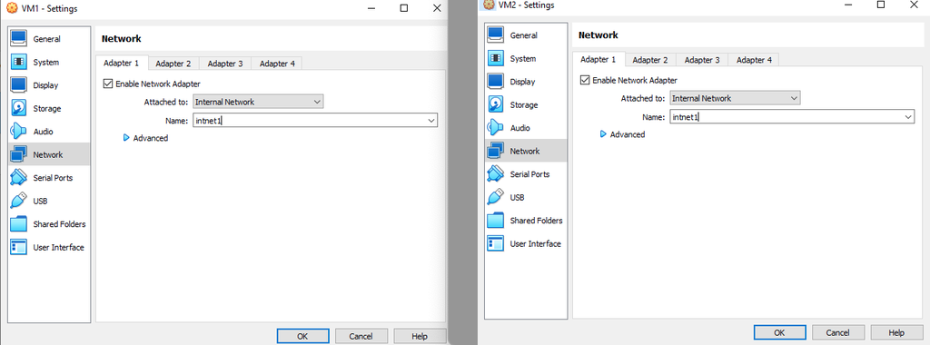

- Après définition du nouveau réseau, on va ajouter un serveur DHCP au réseau "intnet1" pour l'affectation des adresses machines

- Pour créer un serveur DHCP et l'affecter à notre réseau interne "intnet1", il faut utiliser la commande "vboxmanage" accessible sur le dossier d'installation de VirtualBox sur la machine hôte

```
- Pour Windows, la commande "vboxmanage" est localisée sur le chemin suivant : "C:\Program Files\Oracle\VirtualBox"
```

3. Ouvrez l'invite de commandes Windows et changez de répertoire vers le chemin d'accès de la commande "vboxmanage"

```python
cd C:\Program Files\Oracle\VirtualBox
```

[figure not shown]

4. Tapez la ligne de commande suivante :

```python
vboxmanage dhcpserver add --netname intnet1 --ip 10.10.10.1 --netmask 255.255.255.0 --lowerip 10.10.10.2 --upperip 10.10.10.12 --enable
```

- --netname : nom du réseau
- --ip : adresse du serveur DHCP
- netmask : masque réseau
- --lowerip : première adressse de la plage des adresses
- --upperip : dernière adresse de la plage des adresses
- Cette ligne de commande crée un serveur DHCP attaché au réseau "intnet1" avec :
  - Aadresse ip : 10.10.10.1
  - Masque réseau : 255.255.255.0
  - Plage d'adresses : 10.10.10.2 ---> 10.10.10.12

### Test

2. Déterminez l'adresse et le masque réseau ainsi que l'adresse IP de votre machine physique (hôte), de VM1 et VM2

|  | host | VM1 | VM2 |
| --- | --- | --- | --- |
| Adresse IP |  |  |  |
| Masque réseau |  |  |  |
| Adresse réseau |  |  |  |

3. Testez les connexions entre VMs, hôte et réseau Internet et complétez le tableau ci-dessous

| Mode | VM--> VM | VM --> host | host ---> VM | VM ---> Internet |
| --- | --- | --- | --- | --- |
| Internal Network |  |  |  |  |

## Mode accès réseau privé hôte : Host-Only Adapter

- Ce mode est utilisé pour la communication entre machine hôte et VMs
- C’est un réseau fermé entre la VM et la machine hôte.
  - La VM ne peut pas communiquer avec une autre machine que l'hôte et les VMs sur le même réseau
  - Aucune autre machine, de l'extérieur du réseau, que l'hôte ne peut communiquer avec la VM

### Configuration coté hyperviseur

- L'adaptateur du réseau virtuel "Host-Only" est crée sur le système hôte pour l'utilisation dans le mode "Host-Only". Il est accessible sur le menu de VirtualBox : Tools---> Host-Only-Network

[figure not shown]

- Si aucun adaptateur existe, vous pouvez le créer en cliquant sur le bouton "Create"
1. Sous l'onglet "Serveur DHCP / DHCP Server", vérifier que le serveur DHCP est activé

[figure not shown]

2. Arretez les VMS et changez les modes d'accès réseau des deux machines VM1 et VM2 à "Host-only Adapter" et sélectionner le nom correspondant

[figure not shown]

### Test

1. Redémarrez les deux machines
2. Déterminez l'adresse et le masque réseau ainsi que l'adresse IP de votre machine physique (hôte), de VM1 et VM2

|  | host | VM1 | VM2 |
| --- | --- | --- | --- |
| Adresse IP |  |  |  |
| Masque réseau |  |  |  |
| Adresse réseau |  |  |  |

- VM1 et VM2 appartiennent-elles au même réseau?
3. Testez les connexions entre VMs, hôte et réseau Internet et complétez le tableau ci-dessous

[output not shown]

## Port Forwarding

- Dans de cette section, on va faire l'installation d'un serveur web (Apache) sur une VM et configurer l'accès distant pour le mode NAT. Pour ce faire, créez une machine VM3 par clonage de la machine "Base-Ubuntu Desktop". Le mode réseau étant par défaut le mode NAT.

### Installation Apache

1. Sur le terminal, tapez les commandes suivantes pour installer Apache

```python
sudo apt  update
```

```python
apt  install apache2
```

2. Vérifier le statut du service Apache en tapant l'une des commandes suivantes :

```python
sudo systemctl status apache2
```

```python
sudo service apache2 status
```

2. Ouvrez le navigateur web sur l'adressse : "http://localhost:80" (adresse : 127.0.0.1 , port 80) et vérifiez que Apache est bien installé. La page d'accueil Apche2 doit s'afficher

[figure not shown]

### Accès distant au serveur web

1. Est-ce que le serveur web est accessible depuis la machine hôte? le réseau extérieur? Que doit-on faire pour permettre l'accès à distance au serveur web?
2. Changez le mode d'accès réseau de votre VM à "accès par pont /Bridged adapter) et redémarrez votre VM
3. Sur le terminal, tapez la commande "ifconfig" et récupérer l'adresse de votre VM
4. Ouvrez le navigateur de votre machine hôte et tapez l'adresse "http//IP_VM:80". Le serveur web est-il accessible?

### Port Forwarding : Accès distant au serveur web en mode NAT

- Notre objectif est de faire l'accès distant au serveur web tout en gardant le mode d'accès réseau NAT pour la VM. Pour ce faire, on va utiliser le "Port Forwarding"

- Le "Port forwarding" est un processus d'interception du trafic d'une IP et port spécifique (application sur un machine) et sa redirection à une autre IP /port

- Le port forwarding est utilisé pour fournir accès à un service particulier qui est cahé derrière la gateway NAT du réseau externe
- Après configuration du port forwarding, le service devient accessible depuis l'extérieur via une adresse externe et un port
1. Sur votre machine hôte, ouvrez l'invite de commande /terminal et tapez ipconfig (ou ifconfig) pour déterminer l'adresse IP de votre machine physique.
2. Allez sur la console de VirtualBox et sélectionnez la configuration réseau de la machine VM3. Sélectionnez le mode d'accès NAT
3. Sous k'onglet "Avancé /Advanced", cliquez sur "Port Forwarding" et ajoutez la règle suivante (icone en haut à droite) :

| Name | Protocol | Host IP | Host Port | Guest IP | Guest Port |
| --- | --- | --- | --- | --- | --- |
| Rule 1 | TCP | x.x.x.x | 3000 | 10.0.2.15 | 80 |

Avec :

```
- Adresse machine hôte : x.x.x.x
- Adresse machine virtuelle : 10.0.2.15
- Guest Port : port de l'application à accéder (Serveur Apache)
- Host Port : port de la machine hôte (choisissez un port non utilisé)
```

[figure not shown]

6. Ouvrez le navigateur web de votre machine hôte sur l'adressse : "http://x.x.x.x:3000" et vérifiez l'accès à la page d'accueil Apche2

[figure not shown]

###### Virtualisation et Cloud - © TEK-UP University